# How has the Brazilian Amazon been constructed as a problem? The economy, the environment, the people, and the nation in the presidential speeches since 1985

Livio Silva-Muller

Henrique Sposito[^1]

April 2022

Abstract

# 1 Introduction

We need to protect the Amazon from foreign interests. We need to exploit the Amazon’s natural resources. We need to provide better living standards for the people living in the Amazon. We need to preserve the Amazon as a standing ecosystem. Historically, the Brazilian federal government proposed diverse policies to deal with the Amazon. Each of these policies contain an implicit assumption of what needs to be solved, or in other words, it represents the Amazon region, the forest, or its peoples as a particular problem. In the four examples above, the Amazon is represented as an issue of national sovereignty, economic integration, social development, or environmental conservation. Some of these constructions, and their proposed solutions, have been described within policy cycles of Brazilian governments (Acker 2014; Hecht and Cockburn 1990; Hochstetler and Keck 2007). However, policy cycles are usually represented monolithically, advancing a view that specific governments see the Amazon as an instance of only one specific problem. Albeit the current calls to understand the environment as a social-cultural construction and to identify the effect of culture on environmental outcomes (Waroux et al. 2021), we lack empirical accounts of how the Brazilian Amazon has been constructed as a problem in discourses over time, by geographical location, and between and within governments.

In this article, we investigate how the Brazilian Amazon has been constructed as a problem in political discourses. Building on Hirschman (1963) concept of chosen problems in policy making, we propose a framework to identify problem-constructions in political discourses. Although problem-construction takes place in a series of instances (e.g. policy committees, legislative bodies, media, etc.), we analyze the case of discourses by Brazilian presidents since 1985. We opt for presidential speeches for two reasons. First, presidential discourses have the power to introduce and justify public policy, as well as shape its perception to broad audiences (Zarefsky 2004)). In turn, policy perception is key for policy adoption and implementation (Alesina and Giuliano 2009; López et al. 2020). When Brazilian presidents speak about the Amazon it not only makes headlines, nationally and internationally (Brice and Smith 2021; Harris 2021; Miranda 2021), but also incites responses, shapes expectations, and feeds into the behavior of many actors involved in the Amazon, from investors to agribusiness to local farmers. Deforestation rates in Brazil are more responsive to the government’s environmental policy than exogenous factors as market fluctuations (Assunção, Gandour, and Rocha 2015; Capobianco 2019, 2021). Ethnographic research has also shown that policy expectations, generated from material and discursive governmental practices, are a crucial factor in decisions to deforest at the ground (Campbell 2015). Thus, understanding how policy comes about discursively is important. Second, we argue that presidents can employ specific problem-constructions that build objects as specific problems depending on the context. Problem-construction varies by geographic location. Presidential discourses take place in a series of sites with diverse audiences, from launching a new bridge in a small municipality in the middle of the Amazon to a keynote speech in a business association in São Paulo or at the UN general assembly in New York. Working with presidential discourses allows us to identify this variation in meaningful ways and better how the Amazon is socially constructed.

To investigate how the Brazilian Amazon has been constructed as a problem in political discourses, we create a dataset containing 6130 official presidential speeches by all Brazilian presidents since 1985. We subset the dataset by identifying Amazonian related statements within these speeches. We find that 2014 sections in these discourses refer to the Amazon at least once. We then develop a codebook grounded on Amazonian historiography to code how each of these statements constructs the Amazon as a particular problem. We use this codebook to manually code a randomly selected training set of the Amazonian related statements. Using R, we train a supervised machine-learning model in the hand-coded set and automatically label the remaining set of Amazonian statements. We then conduct a descriptive and inferential analysis of this data, tying our findings to endogenous and exogenous events related to deforestation.

This article proceeds as follows: first, we review Amazonian literature to identify the main policy-cycles and their underlying problem construction. We then propose a theoretical framework to understand problem-construction and discourse. In the methodology section, we operationalize our framework and present the codebook. Section four portrays our main results. Finally, we conclude by discussing our findings and proposing future research.

# 2 Amazonian policy-cycles, discourse, and problem-construction

For the purposes of this article, we understand Amazonian literature as the body of research by social and environmental scientists that tells the story of diverse policies adopted to solve problems in the region. The three main policy-cycles we identify in Amazonian literature are: national sovereignty, economic integration, and environmental conservation. We tie each one of them to a specific problem and consequently a solution. We close the sub-section reviewing the relationship between policy, presidential discourse, and environmental problems.

## 2.1 Literature Review: policy-cycles in the Amazonian literature

### 2.1.1 National sovereignty

In The Fate of the Forest: Developers, Destroyers, and Defenders of the Amazon, Hecht and Cockburn write that all over the world tropical forests are destroyed, but “what imbues the case of the Amazon with such passion is the symbolic content of the dreams it ignites” (1990, 1). These dreams of fortunes to be found in the Amazon composed the imaginaries of *bandeirantes*[^2] from the southeast of Brazil and colonizers from everywhere else. It rendered the territory the venue for aspiration and object of an intense scramble in the subsequent centuries, defined as “a (…) form of nation building (…)” (Hecht and Cockburn 1990, preface). The Portuguese empire and subsequently the Brazilian monarchy were concerned with establishing their territory. In the process of securing Amazonian borders, Brazil thwarted “the imperial ambitions of France, Britain, the United States, Belgium, Bolivia, and Peru” (Hecht 2013, 8), and when the dust settled and the scramble was over, half of the Amazon emerged Brazilian. While Brazilian military diplomacy was very successful, the process did not come without its traumas. A significant experience were the negotiations with Bolivia in 1902 to secure the Amazonian state of Acre, during which they found out about American attempts to trick Brazil (Hecht and Cockburn 1990). This case was still part of the memory of the generals who led the country during the military dictatorship of 1964 and wanted to protect Brazil’s sovereignty over the Amazon from the communist threat during the Cold War(Garfield 2013).

As we move from a world where non-state actors gain importance in environmental governance and international politics generally (Silva-Muller and Faul 2022; Andonova 2014; Westerwinter 2021), the sovereignty problem becomes more varied. Multiple non-state actors (NGOs, foundations, IOs, and so on) join the conversation about Amazonian policies more substantially as the military dictatorship starts to end (Hochstetler 2021; Capobianco 2019; Franchini and Viola 2019). Threads to national sovereignty, consequently, can be interpreted as coming from a different set of actors than before. Allegedly false claims about the Brazilian Amazon in international and domestic fora, for instance, are often tied to strategies of ‘internationalizing’ the Amazon. This might come both from foreign actors as well as domestic non-state actors. Relatedly, mentions of Amazonian myths which have been debunked as the ‘Earth of the Lungs’, are also tied to internationalizing strategies.

As we move from a world where non-state actors gain importance in environmental governance and international politics generally (Silva-Muller and Faul 2022; Andonova 2014; Westerwinter 2021), the sovereignty problem becomes more varied. Multiple non-state actors (NGOs, foundations, IOs, and so on) join the conversation about Amazonian policies more substantially as the military dictatorship starts to end (Hochstetler 2021; Capobianco 2019; Franchini and Viola 2019). Threads to national sovereignty, consequently, can be interpreted as coming from a different set of actors than before. Allegedly false claims about the Brazilian Amazon in international and domestic fora, for instance, are often tied to strategies of ‘internationalizing’ the Amazon. This might come both from foreign actors as well as domestic non-state actors. Relatedly, mentions of Amazonian myths which have been debunked as the ‘Earth of the Lungs’, are also tied to internationalizing strategies.

The sovereignty policy-cycle in the Amazon advances the view that the Brazilian Amazon belongs to Brazil while any foreign or non-state, presence in the region is part of a broad strategy to take the region. The policy solutions to the issue of sovereignty, included the monitoring of the borders, strict regimes related to entry in the region, assertions of ownership nationally and internationally, and combatting alleged disinformation from actors perceived as a threat.

### 2.1.2 Economic integration

The Vargas dictatorship (1937-46) and the military dictatorship (1964-89) took over the task of modernizing the Amazon. In 1966, the Brazilian Military launched Operation Amazon, a policy to modernize the region based on a set of assumptions (Acker 2014). First, nature should be conquered by men. Second, exploiting natural resources would render the Amazon region a global powerhouse. Third, such a project would integrate the region with the rest of the country. Concretely, this meant a series of infrastructure projects, such as roads and dams, incentives for settlers to develop ranches and expand the agricultural frontier, and establishing tax free zones to attract industry. The capital to conduct such changes, paradoxically, came from national and international sources (Acker 2014), leading to a series of national and international enterprises settling in the Amazon region. Capobianco (2019) describes the period from the 1950-80 in a similar fashion, referring to a wider range of policies of economic integration: the 1953 Plano de Valorização Econômica da Amazônia; the 1966 Superintendência do Desenvolvimento da Amazônia; the 1967 Superintendência da Zona Franca de Manaus; the 1970 Plano de Integração Nacional; the 1975 Programa Polamazônia; the 1980s Programa Grande Carajás and Programa Calha Norte; among others.

The economic integration problem advances the view that the Brazilian Amazon needs to be developed and modernized. This policy solutions are often centralized by the federal government (Becker 2005) and have at their core the development of the necessary infrastructure (physical, fiscal, or monetary) to integrate the region in the national and international economy.

### 2.1.3 Environmental conservation

The rapid economic changes in the region in the 1960s, 1970s, and 1980s were matched with the birth of environmental institutions such as the New Forest Code (1964), the Secretary of Environment (1973), and the National Environment Law (1980) (Drummond and Barros-Platiau 2006). A common explanation for the creation of these institutions in the Amazonian literature is the impression of lack of control over the market engendered years of centralized economic integration in the region (Acker 2021; Capobianco 2021; Hecht and Cockburn 1990). As deforestation, fires, and violence rose in the region, catching international attention, the military government deemed as necessary the establishment of environmental bureaucracies. This process accelerated in the late 1980s, with the birth of modern environmentalism (Viola 1987) in the 1980s, epitomized in the 1992 Earth Summit in Rio de Janeiro (Hochstetler 2021; Capobianco 2021). Hochstetler and Keck (2007) argue that during preparations for the summit, a new form of Brazilian environmentalism emerged: socio-environmentalism. They define it as an emphasis on local livelihoods of people while protecting nature. Capobianco (2019) argues in a similar line, establishing socio-environmentalism as the main government response in the 1990s and early 2000s in a series of policies: the 2001 Sistema Nacional de Unidades de Conservação; the 2003 Programa Amanônia Sustentavel; the 2004 Plano de Ação para a Prevenção e Controle do Desmatamento na Amazônia Legal; the 2004 Plano BR-163 Sustentável; the 2010 Lei Nacional das Mudanças Climáticas; among others.

The conservationist problem-construction advances the view that Amazon should be preserved, deforestation should be halted, and the sustainable practices of indigenous and local peoples should be maintained through protection of their territories and rights to self-determination (Hochstetler and Keck 2007). The policy solution implies more investment in command-and-control infrastructure (as remote-sensing technology for environmental outcome measurement), more investment in the valuation of standing ecosystems through incentive schemes, and more policies facilitating indigenous environmental practices.

### 2.1.4 Policy and discourse

While policy cycle periods in Amazonian literature have been widely adopted, there is more variation in Amazonian problems and policies than the literature suggests. Different authors have proposed similar periodization for policy-cycles in the Amazon: a focus on sovereignty until the military dictatorship of 1964, followed by strong economic integration policies until the mid 1980s, and finally a shift to conservation after the 1992 Earth Summit. At the macro-historical level, the wider Amazonian vision of the 1964 military dictatorship, encompassed by the whole group of policies they adopted, for instance, did favor economic integration. Nevertheless, at the level of policies adopted, there is more variation than these periods would suggest. For example, the 1980 Projeto Calha Norte had as objectives to protect the borders, integration of the region, and preservation of the forests. Framing this policy as an issue of economic integration, then, can be seen as a choice. Hence, while the literature might represent governments as coherent proponents of a particular policy retroactively, political actors might have adopted strategies that outline problem-constructions of policies differently. For historical inquiry, it is important to periodize policy cycles comprehensively. We largely agree with what the literature assigns to previous governments. However, the possibility of varied portrayals of the same policy opens an understanding agenda-setting and policy-adoption that is less linear.

Problem-construction at the level of discourse is also more varied. They are not monolithic in time, across location, or even by the same speaker. While governmental discourses in Brazil have been studied for topic such as inflation or race relations , we only find one systematic analysis of Amazonian discourse. Barros (2020) investigates Amazonian discourse in the Brazilian Congress with the objective of identifying the arguments put forth by congressmen. The main finding is that the economic value of the Amazon for the cattle industry is the most salient narrative, leading the author to conclude there is a mismatch between the international debate (which focuses on preservation) and the national debate (which focuses on economic development).

Alternatively, several studies analyze environmental discourse in American presidential discourses. Calderwood (2019) examines 2919 mentions of climate change in American official presidential speeches since 1989. Among various findings, one that stands out is that American presidents frequently side-step the environmental aspects of climate change. He also identifies a shift from economic to security framing of climate issues, side-lining its environmental aspects. Calderwood (2020) also tests the effect of geographic location and type of communication regarding climate change. Building prominently on Putnam (1988), he hypothesizes that presidents are more likely to mention climate change in foreign locations, and that location influences the specific discursive approach and tone they adopt. He finds evidence in support of his hypothesis, suggesting American presidential discourse at the top on global warming changes based on location. Elsewhere, Bevitori (2015) investigates how the ‘environment’ has been constructed in American presidential discourse since 1960 using a more automated approach. The author finds that mentions of the environment are typically co-selected with the pronoun ‘our’, as well as with ‘economy’, ‘clean’, and ‘preserve’.

While these findings are US specific, they indicate that presidents raise different points about the Amazon at local, national, or international settings, depending on who they assume their audience is at that specific instance. That entails the same president can combine, substitute, or change how they talk about the Amazon and these views can reflect, or not, the current political scenario, issues in the agenda, or talk to a different policy cycle at times.

## 2.2 Theoretical framework: problem-construction and presidential discourse

In “Journey towards Progress”, Hirschman (1963) analyzes three policy problems in three different Latin American countries. The author draws a conceptual distinction between pressing problems (pressured from outside parties to the government) and chosen problems (chosen by the government at their own discretion). Pressing problems can be either privileged or neglected, depending on the degree of pressure exercised by the interested group. Problems can change from pressing to chosen across time and in space as a function of solutions becoming available, a change of level of government control in society, or a shift of interests from top policymakers (Hirschman 1963, 388–91). Choosing a problem, though, entails a decision on how to represent it (Bacchi 2009). As Bacchi argues, policies have a cultural dimension as “it takes shape within specific historical and national or international contexts”. (2009, 10). The existence or proposal of a policy generally implies that there is a (public) problem that needs (governmental) action to be fixed. The alleged problem is not always explicitly stated in policy. Hirschman exemplifies chosen problems with the case of the construction of Brasilia (1975, 388). But building Brasilia can also be constructed as solving a problem of regional inequality, a problem of a dormant economy without state investment, a problem of political representation, or all three. Different representations speak to different audiences.

Depending on how the problem is represented to be, it can be a solution of problems that are considered pressing. Different problem-constructions can address the demands of different constituencies and it is up to the discretion of the political actor to construct a particular problem in a particular way given context. Problem-construction takes place in different sites: national media, legislative bodies, international fora, policy committees, among others. What eventually becomes policy is a product of a multi-faceted process in all these different sites. One avenue through which governments can emphasize the representations of a problem is discourse. Working on the case of gender discourse, Pike proposes a discursive spectrum approach, where “language serves as an entry point to reveal the range and complexity of attitudes”(2019, 287). Thus, we assume that problem-construction at the level of discourse is varied. They are not monolithic in time, across location, or even by the same speaker.

We argue that presidents can employ specific problem-constructions that build objects as specific problems depending on the context. In the specific case of the Brazilian Amazon, we contend that Amazonian problem-construction connects the region to pressing national issues such as sovereignty, economic integration, social development, or environmental conservation. Presidents choose to represent the region as a particular problem. As Bacchi (2009), we argue that problem-constructions touch on shared meanings about the region that are available to the speaker as part of larger social-cultural history. Thus, the ways a president speaks are culturally and historically mediated and need to be embedded in the wider history of the region and country.

These are the cornerstones of our framework: while governments are sometimes portrayed as proponents of a specific policy-solution, the way they construct the Amazon as a problem varies. The specific problem-constructions that we propose are embedded in Amazonian historiography and connect presidential speeches to Brazilian larger social-cultural history. We propose a framework to understand variation in problem-construction as a choice that is responsive to geographic location, time, and speaker.

# 3 Research Design

## 3.1 Data and modeling: operationalizing Amazonian problem construction

We build upon the dataset provided by (Cezar 2020) which contains all official speeches by Brazilian Presidents from 1985 to 2019 scrapped from the archives of the Brazilian Presidential Library. We update the dataset by scraping and adding all official speeches from 2020 and 2021. The final dataset encompasses 6130 speeches for all the presidents of Brazil since 1985. We then identify all speeches about the Amazon as a region, peoples, or forest out of the 6130 speeches. We do so by detecting all speeches in which the stem “amazon” appears. In Portuguese, the stem captures terms such as “Amazonia”, “Amazonica”, “Amazonidas”, “Amazonense(s)”, “Amazonas”, among others. We find that 946 speeches are, at least partially, about the Amazon from the 6130.

Using the poldis R package, we proceed to extract two sentences before and two sentences after the sentence in which the stem “amazon” appears. We opt for picking two sentences before and two sentences after, rather than words, because sentences usually contain a cohesive idea. By doing so we create our unit of analysis: an Amazonian statement. We use Amazon statements as our unit of analysis for two main reasons. First, working at the level of statements allows us to identify only passages that are meaningful for our specific purpose. Second, it increases the number of our observations and its variety meaningfully, allowing for more specificity in our analysis. This process yields 2014 unique Amazonian statements across the 946 speeches about the Amazon identified. When an Amazonian statement contains two or more matches of the stem “amazon”, we get two sentences before the first match and two sentences after the last match. On average, an Amazonian statement contains 123 words.

With the codebook in hands, each one of the authors, separately, hand-coded the same set of 1007 randomly selected Amazonian statements. This amount refers to 50% of all the Amazon Statements identified. Inter-coder agreement for each of the four main categories was 85%, on average. For each non-matching coded observation, the co-authors discussed and sorted their disagreements. Statements that mention the stem “amazon”, but are not about the Brazilian Amazon, for example, might a greeting to the Governor of the Amazonas, were coded as false positives. The manually coded data is then randomly divided into a training set, containing 80% of the hand-coded observations (806 observations), and a validation set, containing the remaining 20% of the hand-coded data (201 observations). The training set is used to train the supervised machine-learning model that automatically classifies observations while the validation set is used to make sure the model fit is appropriate.

We chose to employ a support-vector machine (SVM) algorithm to label texts, that is, a non-probabilistic linear classifier that classifies documents by assigning points in mapped space to maximize the gap between binary categories [Meyer et al. (2021); Noble (2006)][^3]. After the SVM model is trained and tuned, and the model shows to appropriately fit the validation set, we use the model to automatically code the remaining 1007 Amazonian statements. The model was also trained to identify false positive observations, which we chose to delete for analysis since these are not meaningful statements about the Amazon. The final dataset for analysis contains 1895 coded Amazonian statements. Finally, we use poldis once more to extract locations for all speeches in the data. These locations represent the Brazilian state in which certain speech was given or an international country.

## 3.2 Analysis and limitations

To analyze our data, we first present a series of different plots on proportions of Amazonian statements and problem-constructions over time and by presidents. We control proportions for factors that might affect the incidence of the Amazon in speeches and portray both real and controlled curves. To test whether different problem constructions change according to location, we run a multinomial regression model in which different problem constructions (as categories) are the dependent variable and location is the independent variable. We also control for annual deforestation rates, annual inflation rates, and election years in the model. We interpret the plots and model considering multiple Amazon related events and policies over the last 30 years, as well as their correlations with different presidents and locations, while embedding problem-construction in contemporary happenings.

These procedures come with its limitations. Our codebook is developed using specific Amazon related vocabulary. For example, a statement will be coded as economic integration if it is a meaningful support to the Zona Franca of Manaus or a Dam in the Amazon. However, the economy is generally a topic that presidents speak about. Hence, high incidence of economic integration in Amazonian statements can also be related to the higher importance of this problem-construction in Brazil in time. Moreover, we classify statements as Amazonian based on a dictionary composed of a single lexicon stem: “amazon”. We chose to do so knowing that a few speeches about the Amazon might not contain the lexicon “Amazon”, for example, when the president says, “the forest” or “deforestation”. Hence, we might be missing statements about Amazon that do not refer to it. However, we consider this safer as we cannot be sure that mentions of the forest or deforestation do not correspond to other biomes such as the Cerrado or the Mata Atlantica. Nevertheless, our dataset covers only what is considered an official remark. Presidents, though, give interviews, appear in debates, talk at campaign rallies, and more recently start to appear in social media. Problem-construction within presidential discourse, thus, also happens in different sites for which we do not account for in this paper.

# 4 How has the amazon been constructed as a problem?

This section presents the three main findings of our analysis. We open with a broad overview of the evolution of the incidence of Amazon in all presidential speeches since 1985. In section 4.2, we focus unpack speeches that mention the Amazon, introducing the specific problem-constructions we presented in section 2.1. Finally, we run a multinomial model to show how problem constructions change as the speaker moves further away from the Amazon region.

## 4.1 The rises and falls of the Amazon as a topic in presidential speeches

Figure 1 shows the proportion of speeches that mentions the Amazon in relation to all speeches in each year. The predicted share curve controls incidence for deforestation[^4] , economic situation, and speaker (see appendix for methodological details). We observe various local maxima: 1989, 1992, 2005, 2009, 2015, and 2019. These points coincide with events that help us explain the rises and falls of the Amazon in presidential discourse.

Figure 1 shows the proportion of speeches that mentions the Amazon in relation to all speeches in each year. The predicted share curve controls incidence for deforestation[^4], economic situation, and speaker (see appendix for methodological details). We observe various local maxima: 1989, 1992, 2005, 2009, 2015, and 2019. These points coincide with exogenous events that helps us explain the rises and falls of the Amazon in presidential discourse.

First, we observe a steady increase from about 5% in 1985 to 32% 1989. This is the period when the Brazilian Constitution was being written. Indigenous and traditional populations were instrumental in advocating for constitutional environmental rights and protection of their territories (Hecht and Cockburn 1990). These were eventually enshrined in article 225, which gives all Brazilians a right to a balanced environment, and in article 231, which grants indigenous and traditional populations a right over their territory. Two other factors are likely to explain this increase: in 1988 Chico Mendes was brutally murdered and the New York Times published an article with pictures of the Amazon burning (Simons and Times 1988). Both incidents caught unprecedented international attention. President Sarney responded to these publicly, and proposed a new set of policies to address, named Nossa Natureza (Capobianco 2021).

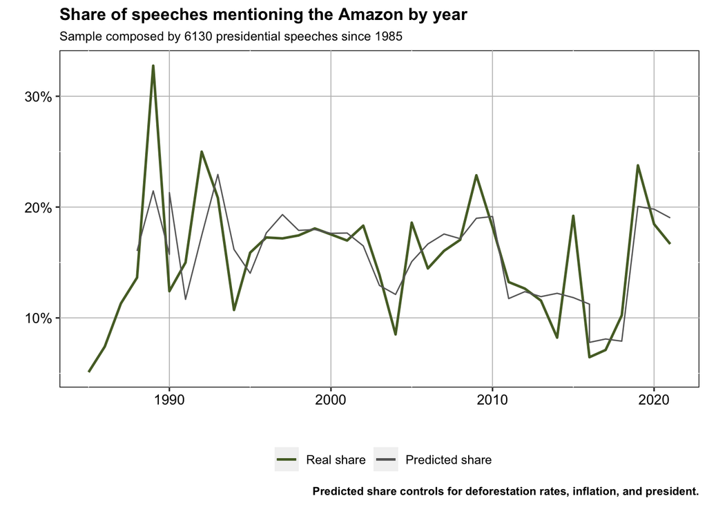

While in 1990 there was a decrease to about 12.4%, we observe a novel increase to 15% and 25% in 1991 and 1992 respectively. The driver of this increase is likely to be the 1992 Earth Summit, which was being prepared by various state and non-state actors in the region and brought international attention to environmental topics in Brazil. One of the big announcements was the consolidation of the first transnational partnership for the Amazon, the G7 Pilot Programme, which brought a high number of financial resources to the region for public policy implementation (Capobianco 2021). During the Cardoso years (1994-2002), Amazonian speeches averaged at about 16% without strong variation. There were no major international or domestic events that drove the topic up.

We observe an increase from 8.5% in 2004 to 22.8% in the year of the Copenhagen Summit, 2009. This coincides with the Presidency of Lula and the steepest decrease in deforestation rates since data is available. Lula led the delegation to Copenhagen with a self-image of “we do not promise, we deliver” (Franchini and Viola 2019), when stakes about climate change were high. A somewhat different pattern can be identified in the lead up to the 2015 Paris COP, which was also building up to become a key-turn in climate politics after the failures of Copenhagen. From 2010 to 2014, we identify a steady decrease from 18.2% to 8.2%, which is followed by a sharp increase in the year of the COP, reaching 19.2%. Disagreements related to the priority of environmental preservation over economic development, most notably in the case of Itaipu Dam, led the environmental minister Marina Silva to resign and run for presidency on her own agenda in 2010. These are also the years when Brazil entered a long period of political and economic instability, which led to the impeachment of Dilma Roussef . Brazil went to the Paris COP with deforestation numbers slightly higher than Copenhagen, and a perception that there was a turn towards less conservation since Marina Silva left the government and the 2011 New Forest Code was approved.

We subsequently observe a steady increase from 6.4% in 2016 to almost 24% in the first year of Bolsonaro’s presidency, 2019. As the narrative of the climate crisis picks up in the late 2010s, international media attention about the Amazon blasts reach unprecedented coverage. Pictures of the Amazon on fire and of the red sky afternoon in São Paulo circulated in social media and international media outlets in 2019. President Bolsonaro engages in an international debacle with President Macron and others, which drove the topic up strongly in the presidential agenda. President Bolsonaro retrieves Brazil’s hosting status for COP25, and a strong process of dismantling of environmental governance starts taking place.

The local maxima of the graphs, both controlled and real, suggest that international events and media coverage also correlate with presidents speaking about the Amazon. We are yet to inspect, though, whether specific problem constructions about the Amazon change over time.

## 4.2 Amazonian problem-construction in time

Figure 2 portrays plots with the proportions of different mixed and pure problem constructions over time. We conceptualize four pure problem constructions: sovereignty, economic integration, social development, and conservation. At the level of the speech, though, presidents might mix multiple problem construction in an Amazonian statement . These are what we call mixed types. Pure problem constructions dominate, with their joint average at 55.8%. We observe a strong variation over time for most of these constructions, suggesting the narratives do respond differently to factors that affect Amazonian statements, some of which was discussed in the section above.

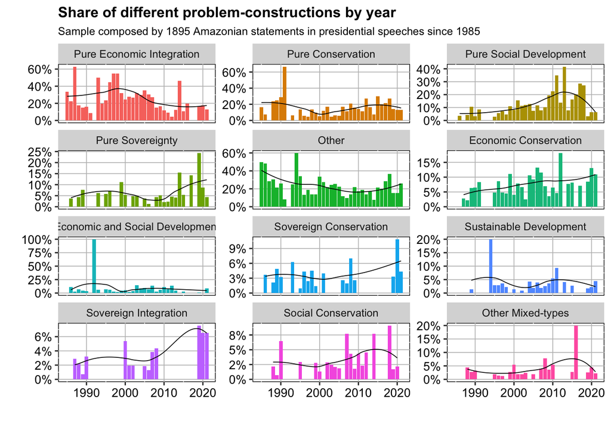

The plots reveal several trends. We start with analyzing pure types. Pure economic integration statements, which were dominant, decreased in incidence as of the late 1990s. Concurrently , pure conservation as well as pure social development increased; both surpassing the proportion of economic integration problem-construction in 2010. President Cardoso deemed as responsible for solving the national problem of inflation, was the main user of the economic integration problem construction. With the end of his presidency, environmental conservation starts increasing. Capobianco (2021) argues that the unprecedented decrease in deforestation we observed from 2004 to 2012 was a product of an increase in the perception of stronger federal policies and presence in the Amazon region, which in turn engendered a perception of higher risk of being caught and fined for deforestation. This correlates with our findings: a higher incidence of the Amazon as a topic overall can generate a perception of more attention from the top, and a shift from economic integration to conservation can generate a perception of higher chance of being caught for illegal deforestation.

As of the mid 2010s, we a reverse of this trend with a twist: economic integration starts picking up again in detriment of conservation and social development problem constructions, but with sovereignty increasing steadily. Figure 3 (below) shows these shifts and reversal more clearly. It highlights the decrease of economic integration and increase of social and conservation problem constructions preceding Lula’s presidential mandate. Relatedly, figure 3 also shows that while the reversal precedes the mandate of President Bolsonaro, it was with him and his dismantling of social and environmental policies that sovereignty and economic integration reaches their actual maximum and a new local maximum (respectively).

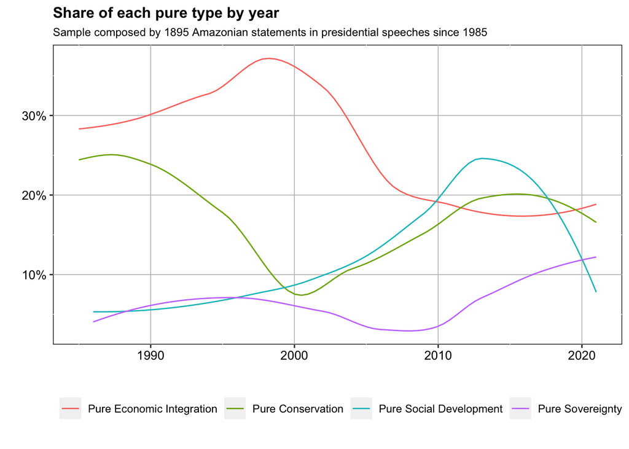

We interpret the appearance of mixed types as more complex understandings of Amazonian problems. All other mixed types appeared less than 2.6% on average in relation to all statements. We can also interpret mixed types, though, by looking at what composes them time. Mixed types using conservation were quite frequent in the lead up and aftermath of the 1992 Earth Summit. This includes the mix type we label sustainable development, which constructs the Amazon as a problem of economic integration, social development, and environmental conservation. This follows a global agenda of understanding interconnections of social, environmental, and economic domains. As we show that Amazonian incidence in discourse does respond to global issues, this is not a surprise given agendas such as the Millennium Development Goals and the Sustainable Development Goals.

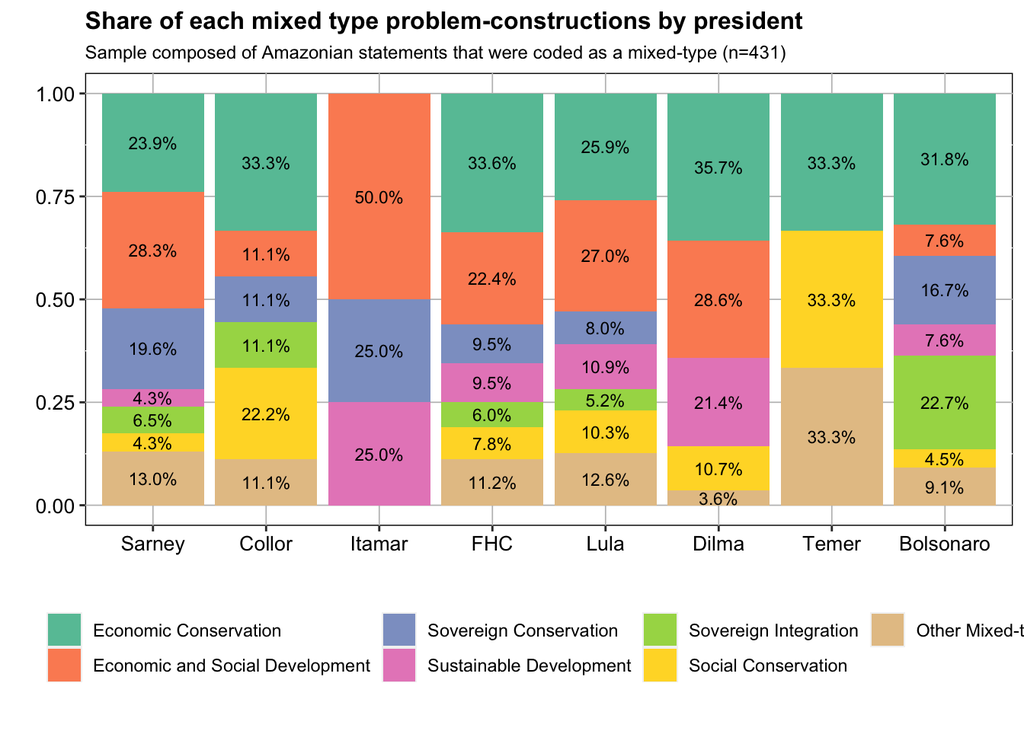

## 4.3 An Amazonian three-level game? Boasting policy outside, talking to people inside

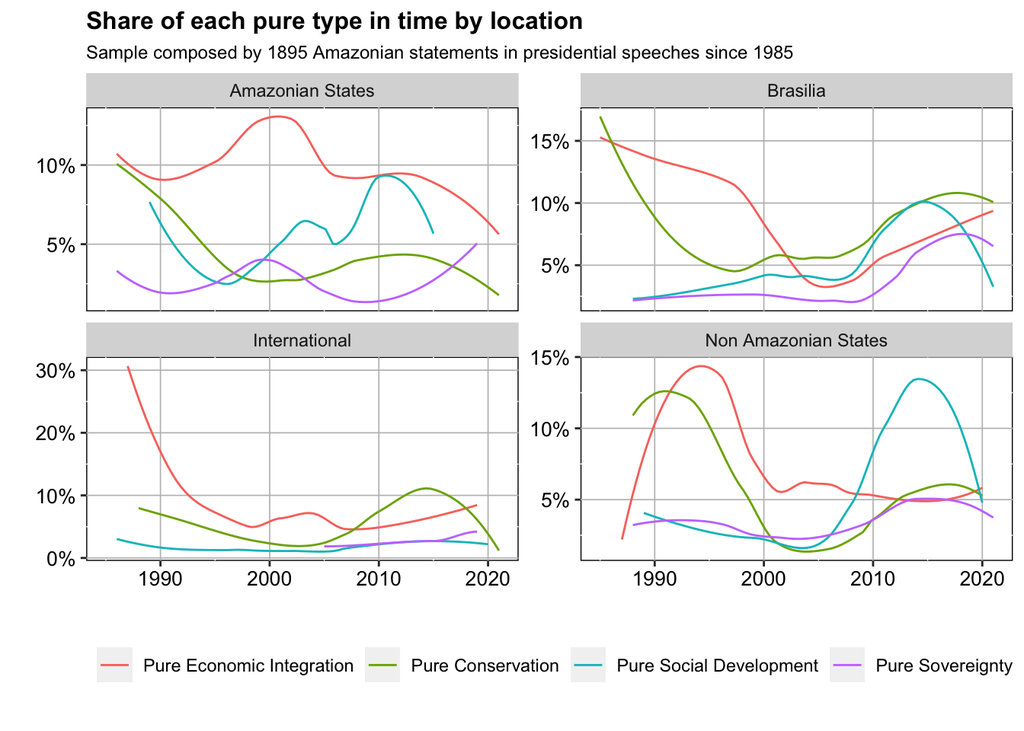

Table 2, below, displays the multinomial regression coefficients for the correlation between diverse problem constructions and locations. The regression coefficients express the log odds, that is, the logarithm odds to the reference categories. The reference categories are Amazonian states for location and environmental conservation for problem construction. To facilitate visualization, since the model has many more columns (i.e. types of problem construction), we only display the model results for the pure-type constructions, however, the model does account for both pure and mixed-type constructions. We keep the results for the control variables for election year, annual deforestation rates, and average yearly inflation in the table.

The results indicate that the presidents are more likely to construct it as an environmental conservation problem far away from the Amazon. The negative statistically significant coefficients of problem constructions such as pure economic integration and pure social development in both international settings and Brasilia, in relation to environmental conservation problem constructions in Amazonian states, indicate that presidents are less likely to construct the Amazon as an issue of economic integration and social development in those locations. That is, presidents are more likely to construct the Amazon as an issue of environmental conservation in international settings and in Brasilia than in Amazonian states.

Table 2 - Amazon Problem-Construction by Location

| Dependent Variable | Economic Integration vs Environmental Conservation | Social Development vs Environmental Conservation | Sovereignty vs Environmental Conservation |
| --- | --- | --- | --- |
| Brasilia vs Amazonian States | -1.024*** | -1.002*** | -0.206 |
| International vs Amazonian States | -0.612*** | -1.583*** | -1.427*** |
| Other States vs Amazonian States | 0.023 | -0.041 | 0.324 |
| Election Year | -0.241 | 0.028 | -0.684** |
| Annual Deforestation | 0.063*** | -0.031* | 0.004 |
| Average Inflation | -0.001*** | -0.001*** | -0.0001 |

Constructing the Amazon as an issue of economic integration correlates with increases in deforestation rates. Some of the control variables correlate with some Amazonian problem constructions in interesting ways. For example, pure sovereignty constructions correlate negatively with election years in relation to conservation. That is, in election years conservation constructions are more likely to take place in comparison to sovereignty. As well, annual deforestation rates correlate positively with economic integration constructions in relation to conservation. This indicates that as deforestation increases, presidents are also more likely to construct the Amazon as an issue of economic integration, or vice-versa.

Putnam (1988) seminal article on the two level game between domestic and international politics analyzes how negotiations at both levels make policies possible. The author argues that both domestic and international levels need to be taken into consideration when analyzing how, often, domestic politics became entangled in international negotiations. The Amazon, as a region and a forest, has been the topic of international negotiations, national debates, and local policy implementation; though how the Amazon has been constructed as an issue differs on each of these three levels. While in Brasilia or internationally different presidents might construct the Amazon as an issue of conservation, the same presidents might construct the Amazon as an issue of economic integration or social development at the local level. This implies not only that audiences’ priorities in each setting change, but that which policies are appropriate to solve the “Amazon issue” differ. The three level game entails that conservation might be a desirable construction when speaking internationally about the Amazon, but not for local electorates. Such might help explain diverse local implementation gaps between public policy negotiated outside and implemented within the Amazon as perceptions and expectations about the issues the same policy addresses might differ (Alesina and Giuliano 2009; López et al. 2020).

# 5 Discussion: The Amazon frontier, environmentalism, and democracy

Pacheco (2019) proposes that we see the Amazon frontier as a key analytic category to understand the Brazilian state and democracy. Specifically, the author states that the natural richness of the region has been instrumentally transformed in political support through resource exploration by different governments over the last centuries. The costs for said economic benefits are the livelihoods of indigenous and traditional populations and the ecosystems they reside in. Political stability, thus, can be seen as a product of the trade-off between both. Policies during the military dictatorship were strongly geared towards integrating the Amazon to the national territory and international economy. These were times when deforestation increased, but political stability was achieved as those bearing the costs of said deforestation were being targeted. Generally high levels of violence in the region, epitomized in the assassination of Chico Mendes, serve as evidence for that (Hecht and Cockburn 1990).

The Amazon frontier as an analytic category can help us shed light on the differences we identify between the discourse in Amazonian States compared to Brasilia and other States. Whereas presidential discourses at the top matter to define and justify public policy (Zarefsky 2004), presidents shape their discourses according to who their audience might be and what “they want to hear”. If presidents promote an agenda of economic and social development within Brazil that diverges from the one the president promotes outside of Brazil, the question for democracy becomes to what extent the implemented agenda responds to domestic versus international demands. Or, as Putnam (1988) puts, what’s the actual overlap between international and domestic overlap. The domestic policies and transnational support that led to the decrease of deforestation from 2004 to 2012 happened concurrently to a period of strong economic growth and social development in Brazil and worldwide. With the strengthening of environmentalism and indigenous participation in politics in the late 1980s and 1990s, we can interpret the fall of economic integration and the rise of social and conservation problem constructions as a new relationship between granting local livelihoods their rights and economic exploitation.

While unprecedented, this new balance was not long-standing. Democratic decay is slow, and the embryo of Bolsonaro’s Amazonian discourse was breeding half a decade before he took office. We observe the decrease in conservation related statements in the mid 2010s, and the soft increase of sovereignty both pure and in mixes already late 2000s (figure 3). The hard increase in sovereignty comes in the early 2010s. As we conceptualize and operationalize sovereignty as boundary-making vis-à-vis internal and external perceived threats to the Amazon, we interpret this increase as attacks to indigenous and traditional populations. At the policy side, the Itaipu Dam in the late 2000s and the 2011 Forest code are seen as a turning point: political opposition to conservation got particularly organized and managed to lobby the executive and conquer this policy wins, which were largely opposed by environmentalists. The political forces in Brazilian democracy that drive these changes in problem-construction were long in the making, as the earlier and softer shifts in discourse suggest. Bolsonaro’s problem-construction is the strongest form of this shift.